# Lec9

Anna Toidze, MIkhail Slizen, Pavel Vychyk

11/24/2021

#Project Anova

We examine the data about patients treating with different kinds of drugs and their influence on the numbe rof days the patients stay in the hospital.

Let’s see how our data looks like:

```bash
ls Data/
```

```
## 10.csv
## 11.csv
## 12.csv
## 13.csv
## 14.csv
## 15.csv
## 16.csv
## 17.csv
## 18.csv
## 19.csv
## 1.csv
## 20.csv
## 2.csv
## 3.csv
## 4.csv
## 5.csv
## 6.csv
## 7.csv
## 8.csv
## 9.csv
```

**1.** So we have 20 .csv files, that have to unite in one table. Let’s load the needed libraries:

```r
packages <- c("ggplot2", "dplyr", "ggExtra", "cowplot", "car", "broomExtra", "purrr", "stringr", "data.table", "gridExtra")
package.check <- lapply(
  packages,
  FUN = function(x) {
    if (!require(x, character.only = TRUE)) {
      install.packages(x, dependencies = TRUE)
      library(x, character.only = TRUE)
    }
  }
)
```

Uniting all data in one datafram *df*:

```r
uniting_data <- function(path, extension = "csv"){
  pattern <- paste0("*.", extension)
  myfiles <-  paste0(path, list.files(path, pattern=pattern, all.files=FALSE,
           full.names=FALSE))
  rbindlist(lapply(myfiles, function(x){read.csv(x, stringsAsFactors = F, sep=',')}))
}
path <- "Data/"

df <- uniting_data(path)
```

**2**. Tidying up data, substituting incorrect values:

```r
unique(df$age)
```

```
##  [1] "26"         "31"         "28"         "29"         "30"
##  [6] "36"         "24"         "37"         "27"         "32"
## [11] "33"         "25"         "35"         "34"         "thirty-one"
## [16] "350"        "220"        "23"
```

```r
df <- df %>% mutate(age=replace(age, age == "thirty-one", 31))
df$age <- as.numeric(df$age)
str(df)
```

```
## Classes 'data.table' and 'data.frame':   200 obs. of  7 variables:
##  $ X               : int  1 2 3 4 5 6 7 8 9 10 ...
##  $ gender          : chr  "female" "female" "female" "female" ...
##  $ age             : num  26 26 31 28 29 30 36 31 31 30 ...
##  $ drug_type       : chr  "Placebo" "Placebo" "Placebo" "Placebo" ...
##  $ is_relapse      : int  0 1 0 1 1 NA 0 1 1 0 ...
##  $ id              : int  101 102 103 104 105 106 107 108 109 110 ...
##  $ days_in_hospital: num  25.2 23.3 29.9 27.8 23.3 ...
##  - attr(*, ".internal.selfref")=<externalptr>
```

```r
df$gender <- factor(df$gender)
str(df)
```

```
## Classes 'data.table' and 'data.frame':   200 obs. of  7 variables:
##  $ X               : int  1 2 3 4 5 6 7 8 9 10 ...
##  $ gender          : Factor w/ 3 levels "female","male",..: 1 1 1 1 1 1 1 1 1 1 ...
##  $ age             : num  26 26 31 28 29 30 36 31 31 30 ...
##  $ drug_type       : chr  "Placebo" "Placebo" "Placebo" "Placebo" ...
##  $ is_relapse      : int  0 1 0 1 1 NA 0 1 1 0 ...
##  $ id              : int  101 102 103 104 105 106 107 108 109 110 ...
##  $ days_in_hospital: num  25.2 23.3 29.9 27.8 23.3 ...
##  - attr(*, ".internal.selfref")=<externalptr>
```

```r
unique(df$gender)
```

```
## [1] female male   malle
## Levels: female male malle
```

```r
df <- df %>% mutate(gender=replace(gender, gender == "malle", "male"))
unique(df$drug_type)
```

```
## [1] "Placebo"    "New_type_2" "New_type_1" "Old_type"
```

```r
unique(df$X)
```

```
##   [1]   1   2   3   4   5   6   7   8   9  10  91  92  93  94  95  96  97  98
##  [19]  99 100 101 102 103 104 105 106 107 108 109 110 111 112 113 114 115 116
##  [37] 117 118 119 120 121 122 123 124 125 126 127 128 129 130 131 132 133 134
##  [55] 135 136 137 138 139 140 141 142 143 144 145 146 147 148 149 150 151 152
##  [73] 153 154 155 156 157 158 159 160 161 162 163 164 165 166 167 168 169 170
##  [91] 171 172 173 174 175 176 177 178 179 180 181 182 183 184 185 186 187 188
## [109] 189 190  11  12  13  14  15  16  17  18  19  20 191 192 193 194 195 196
## [127] 197 198 199 200  21  22  23  24  25  26  27  28  29  30  31  32  33  34
## [145]  35  36  37  38  39  40  41  42  43  44  45  46  47  48  49  50  51  52
## [163]  53  54  55  56  57  58  59  60  61  62  63  64  65  66  67  68  69  70
## [181]  71  72  73  74  75  76  77  78  79  80  81  82  83  84  85  86  87  88
## [199]  89  90
```

```r
unique(df$days_in_hospital)
```

```
##   [1] 25.18238 23.26929 29.86716 27.82082 23.27875 24.66779 27.57351 31.80577
##   [9] 22.44383 23.51190 24.36178 19.06414 24.03859 19.63718 25.58169 18.30608
##  [17] 24.61532 17.26029 20.22895 20.09939 24.79150 25.51997 25.74334 23.13876
##  [25] 23.78566 27.26671 22.96677 23.52742 24.40915 23.82294 24.57628 22.09928
##  [33] 26.75551 21.25727 26.48681 21.54828 23.87264 22.97856 22.59301 26.26239
##  [41] 20.96629 24.65274 22.53188 25.88804 22.97947 24.56527 22.08336 28.21025
##  [49] 24.74948 25.56154 27.16865 24.11292 28.00985 22.78162 28.90763 22.47703
##  [57] 23.53802 24.00939 23.55261 25.33759 23.72419 24.67166 25.02606 21.61933
##  [65] 26.75161 25.30256 24.19273 28.34520 22.82666 25.67250 14.83553 12.61460
##  [73] 23.34745 21.19046 21.57153 21.99721 20.28922 20.24597 24.18043 16.14910
##  [81] 21.26081 25.34861 24.30012 15.67820 24.54947 22.49700 22.85721 19.57692
##  [89] 13.59000 25.85534 21.48861 18.84284 22.55702 22.52141 28.11908 30.05022
##  [97] 32.13245 27.93743 37.72459 34.27224 29.16057 26.03458 31.28663 30.56511
## [105] 28.25790 32.64008 32.73939 31.73783 35.43289 26.95608 26.12882 22.29611
## [113] 26.35784 24.57152 26.85415 27.15460 28.76379 23.28021 26.15791 28.66906
## [121] 30.53312 32.30066 27.31526 27.85904 28.19487 35.17823 33.72636 23.92227
## [129] 29.82660 28.60610 28.41443 25.45691 24.14047 23.07201 25.37566 23.26235
## [137] 26.91677 25.38070 27.66797 23.39366 27.64067 23.75104 26.80564 22.56180
## [145] 22.53678 27.82001 24.66945 27.86130 26.63532 22.35497 18.90696 23.89786
## [153] 25.95670 23.80889 26.19601 22.03567 26.30333 23.23972 22.41623 23.83418
## [161] 24.32108 26.77002 33.75272 28.06817 35.72671 27.34432 30.35893 33.95622
## [169] 26.62029 31.95320 27.29391 33.94030 25.39837 25.25799 30.66181 28.58425
## [177] 28.69897 30.14202 30.64702 33.02891 29.68087 30.72840 28.91956 31.13790
## [185] 26.79249 19.22815 19.96191 24.65521 17.59923 27.05847 25.45581 18.18105
## [193] 26.10279 17.92937 20.04565 23.24598 23.48320 20.47848 26.29038 26.39834
```

Everything else seems to be fine. **3.** Calculate mean and standard deviation of the number of days, required to leave the hospital.

```r
df %>% select(days_in_hospital) %>%
  summarise(mean = mean(days_in_hospital),
            stdev = sd(days_in_hospital))
```

```
##       mean  stdev
## 1 25.32267 4.1972
```

**4.** Number of days spent in hospital, depending on sex:

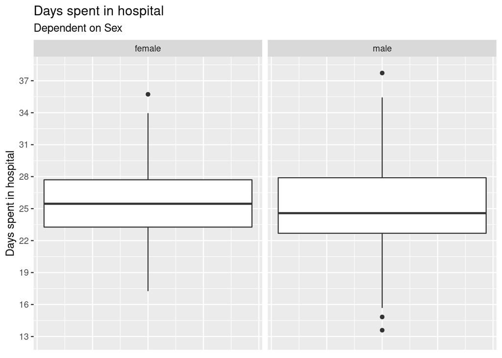

```r
ggplot(df, aes(y = days_in_hospital)) +
  geom_boxplot()+
  labs(title= "Days spent in hospital",
       subtitle = "Dependent on Sex")+
  ylab("Days spent in hospital")+
  theme(axis.title.x=element_blank(),
        axis.text.x=element_blank(),
        axis.ticks.x=element_blank())+
  scale_y_continuous(limits = c(round(min(df$days_in_hospital, na.rm = T)),
 round(max(df$days_in_hospital, na.rm = T))), breaks = seq(round(min(df$days_in_hospital, na.rm = T))
, round(max(df$days_in_hospital, na.rm = T))
, round((max(df$days_in_hospital, na.rm = T)-min(df$days_in_hospital, na.rm = T))/10)
)) +
  facet_grid(. ~ gender)
```

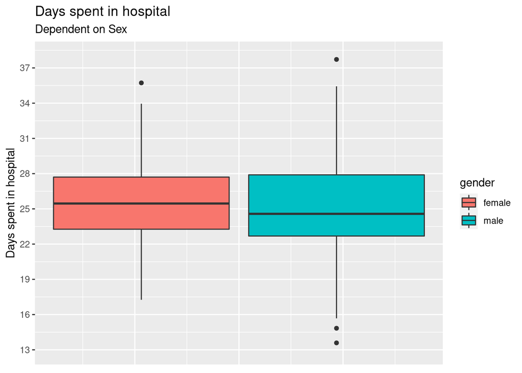

```r
ggplot(df, aes(y = days_in_hospital, fill = gender)) +
  geom_boxplot()+
  labs(title= "Days spent in hospital",
       subtitle = "Dependent on Sex")+
  ylab("Days spent in hospital")+
  theme(axis.title.x=element_blank(),
        axis.text.x=element_blank(),
        axis.ticks.x=element_blank())+
  scale_y_continuous(limits = c(round(min(df$days_in_hospital, na.rm = T)),
 round(max(df$days_in_hospital, na.rm = T))), breaks = seq(round(min(df$days_in_hospital, na.rm = T))
, round(max(df$days_in_hospital, na.rm = T))
, round((max(df$days_in_hospital, na.rm = T)-min(df$days_in_hospital, na.rm = T))/10)
))
```

**5.** Is there a significant difference between days spent in hospital for women, which were taking placebo or drug type 2.

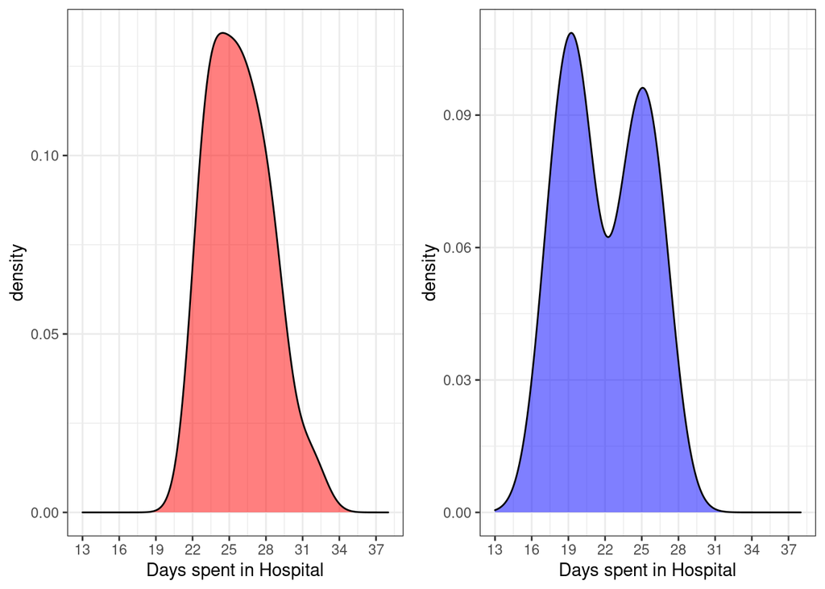

```r
#Checking if normally distributed
wdf_plac <- subset(df, gender == "female" & drug_type == "Placebo")
plac <- ggplot(wdf_plac, aes(days_in_hospital))+
  geom_density(fill = "red", alpha = 0.5)+
  scale_x_continuous(name = "Days spent in Hospital",
                     limits = c(round(min(df$days_in_hospital, na.rm = T)),
 round(max(df$days_in_hospital, na.rm = T))), breaks = seq(round(min(df$days_in_hospital, na.rm = T))
, round(max(df$days_in_hospital, na.rm = T))
, round((max(df$days_in_hospital, na.rm = T)-min(df$days_in_hospital, na.rm = T))/10)
)) +
  theme_bw()
wdf_2 <- subset(df, gender == "female" & drug_type == "New_type_2")
type2 <- ggplot(wdf_2, aes(days_in_hospital))+
  geom_density(fill = "blue", alpha = 0.5)+
  scale_x_continuous(name = "Days spent in Hospital",
                     limits = c(round(min(df$days_in_hospital, na.rm = T)),
 round(max(df$days_in_hospital, na.rm = T))), breaks = seq(round(min(df$days_in_hospital, na.rm = T))
, round(max(df$days_in_hospital, na.rm = T))
, round((max(df$days_in_hospital, na.rm = T)-min(df$days_in_hospital, na.rm = T))/10)
)) +
  theme_bw()

plot_grid(plac, type2)
```

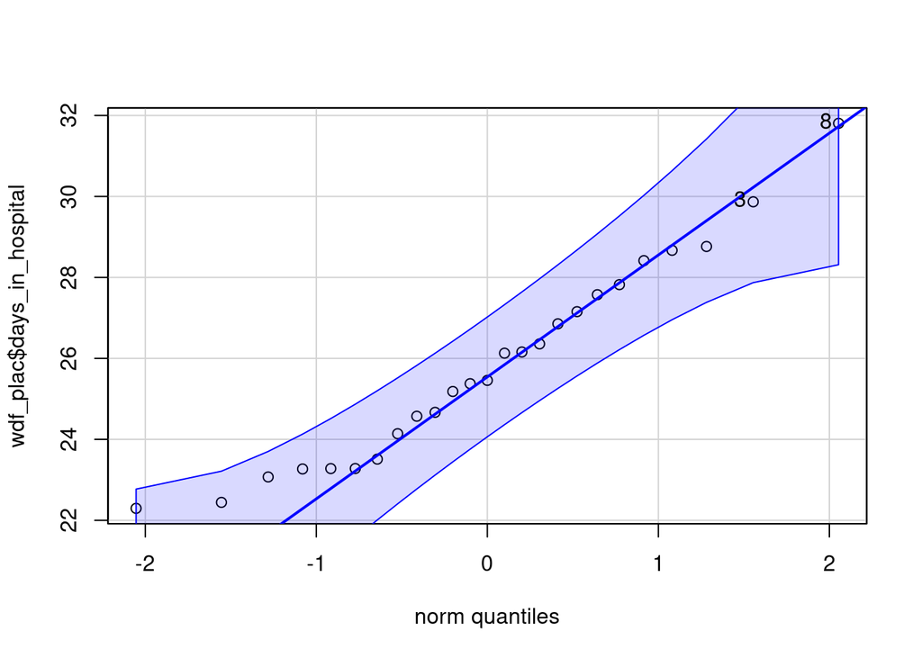

```
## [1] 8 3
```

```r
#Plot

qqPlot(wdf_plac$days_in_hospital) #normally distributed
```

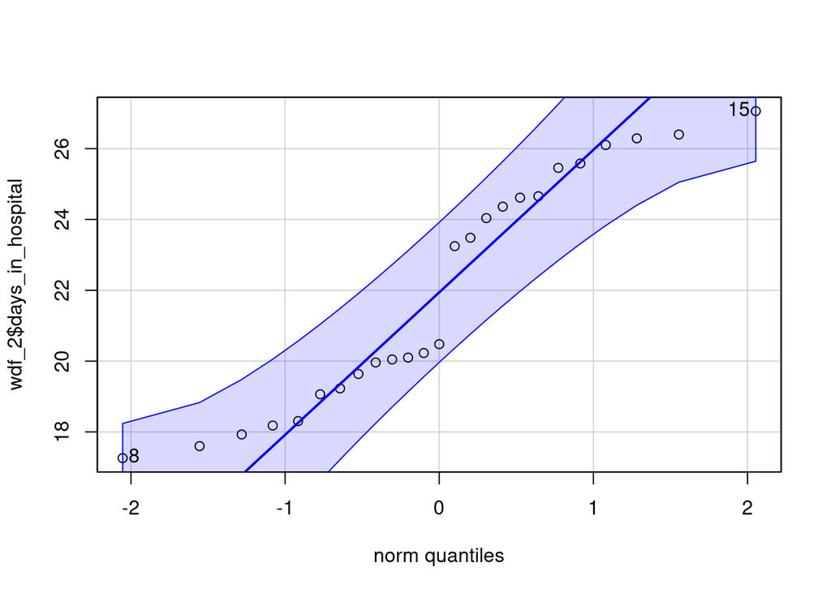

```
## [1] 15  8
```

```r
qqPlot(wdf_2$days_in_hospital) #not normally distributed
```

```r
#Shapiro test for normal distribution
shapiro.test(wdf_plac$days_in_hospital) #normally distributed
```

```
##
##  Shapiro-Wilk normality test
##
## data:  wdf_plac$days_in_hospital
## W = 0.95885, p-value = 0.392
```

```r
shapiro.test(wdf_2$days_in_hospital) #not normally distributed
```

```
##
##  Shapiro-Wilk normality test
##
## data:  wdf_2$days_in_hospital
## W = 0.89985, p-value = 0.01821
```

As we can see, our data is not normally distributed (specifically days spent in hospital for females receiving drug type 2) and the number of observations is not really that big. It follows that t-test cannot be used, but instead Mann-Whitney U-test:

```r
#Mann-Whitney U test
wlic <- wilcox.test(wdf_plac$days_in_hospital, wdf_2$days_in_hospital)
wlic <- tidy(wlic)
names(wlic) <- c("Statistic", "P Value", "Method", "Alternative Hypothesis")
wlic
```

```
## # A tibble: 1 × 4
##   Statistic `P Value` Method                       `Alternative Hypothesis`
##       <dbl>     <dbl> <chr>                        <chr>
## 1       497  0.000221 Wilcoxon rank sum exact test two.sided
```

Description as in article: Days spent in hospital of females receiving place and drug of type 2 were compared. As the sample size was quite small and the days spent in hospital, Mann-Whitney test was run with test statistic equal to 497 and p-Value of 2.2051037^{-4}. It can be concluded, that the days spent in hospital significantly defer from each other. **6.** Is there a difference in the number of days spent in the hospital between taking a drug and placebo?

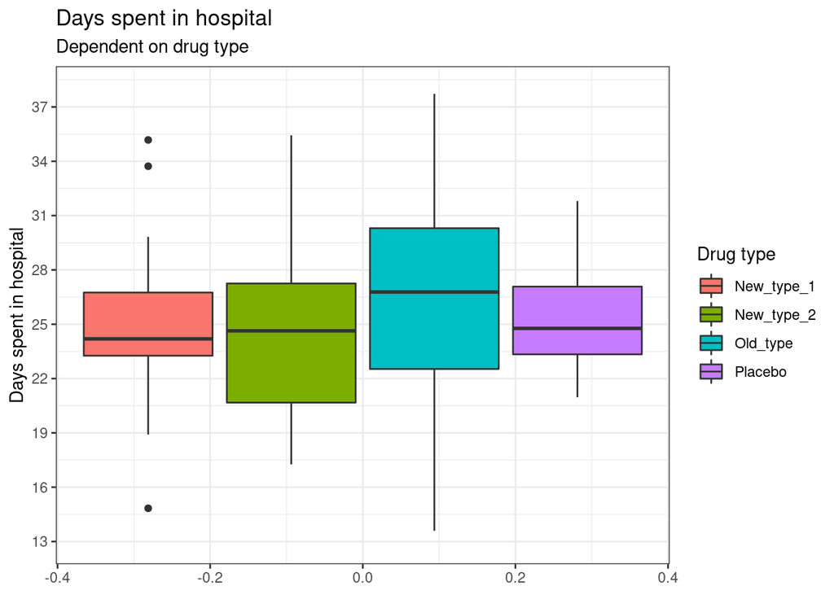

```r
ggplot(df, aes(y = days_in_hospital, fill = drug_type))+
  geom_boxplot()+
    labs(title= "Days spent in hospital",
       subtitle = "Dependent on drug type")+
  ylab("Days spent in hospital")+
  theme(axis.title.x=element_blank(),
        axis.text.x=element_blank(),
        axis.ticks.x=element_blank())+
  scale_y_continuous(limits = c(round(min(df$days_in_hospital, na.rm = T)),
 round(max(df$days_in_hospital, na.rm = T))), breaks = seq(round(min(df$days_in_hospital, na.rm = T))
, round(max(df$days_in_hospital, na.rm = T))
, round((max(df$days_in_hospital, na.rm = T)-min(df$days_in_hospital, na.rm = T))/10)
))+
  scale_fill_discrete(name = "Drug type")+
  theme_bw()
```

There doesn’t really seem to be much difference, though let’s check with one-way anova. Null hypothesis - the means of th different groups are the same. Alternative hypothesis - at least one sample mean is not equal to others. Conditions:

1. Independent and random observations from factors
2. Data for each factor normally distributed
3. They have common variance

Checking for **normal distribution**:

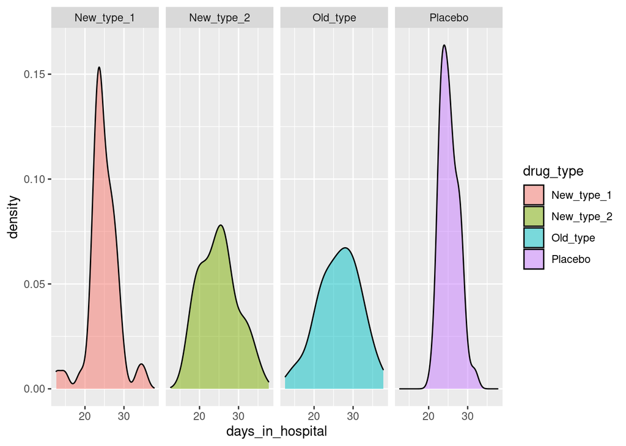

```r
ggplot(df, aes(days_in_hospital, fill = drug_type))+
  geom_density(alpha = 0.5)+
  facet_grid(. ~ drug_type)
```

```r
shapiro.test(df[drug_type=="Placebo", ]$days_in_hospital) #normally distributed
```

```
##
##  Shapiro-Wilk normality test
##
## data:  df[drug_type == "Placebo", ]$days_in_hospital
## W = 0.96695, p-value = 0.1734
```

```r
shapiro.test(df[drug_type=="Old_type", ]$days_in_hospital) #normally distributed
```

```
##
##  Shapiro-Wilk normality test
##
## data:  df[drug_type == "Old_type", ]$days_in_hospital
## W = 0.99036, p-value = 0.9541
```

```r
shapiro.test(df[drug_type=="New_type_1", ]$days_in_hospital) #not normally distributed :(
```

```
##
##  Shapiro-Wilk normality test
##
## data:  df[drug_type == "New_type_1", ]$days_in_hospital
## W = 0.91886, p-value = 0.002146
```

```r
shapiro.test(df[drug_type=="New_type_2", ]$days_in_hospital) #normally distributed
```

```
##
##  Shapiro-Wilk normality test
##
## data:  df[drug_type == "New_type_2", ]$days_in_hospital
## W = 0.96725, p-value = 0.1785
```

Based on the Shapiro-Wilk test data for each factor is normally distributed, except for new drug of type 1. However, p value is 0.0021455, and not that low, and based on the density distribution - it is not bimodal, so it still okay to use the Anova test.

Checking for common variance with **Levene’s test for homogeneity of variance**:

```r
lev <- leveneTest(days_in_hospital ~ drug_type, df)
lev$`Pr(>F)`[1]
```

```
## [1] 8.030055e-06
```

Based on the Levene’s test (p_value = 8.0300548^{-6}), we are not allowed to do the ANOVA-test, because there is statistically different variance across groups.

Let’s continue:

```r
df %>% group_by(drug_type) %>%
  summarise(
    count = n(),
    mean = mean(days_in_hospital, na.rm = TRUE),
    sd = sd(days_in_hospital, na.rm = TRUE)
  )
```

```
## # A tibble: 4 × 4
##   drug_type  count  mean    sd
##   <chr>      <int> <dbl> <dbl>
## 1 New_type_1    50  24.7  3.72
## 2 New_type_2    50  24.9  4.73
## 3 Old_type      50  26.4  5.31
## 4 Placebo       50  25.3  2.30
```

```r
table(df$drug_type)
```

```
##
## New_type_1 New_type_2   Old_type    Placebo
##         50         50         50         50
```

The count of data is same. Let’s take at variances (code adapted from lecture):

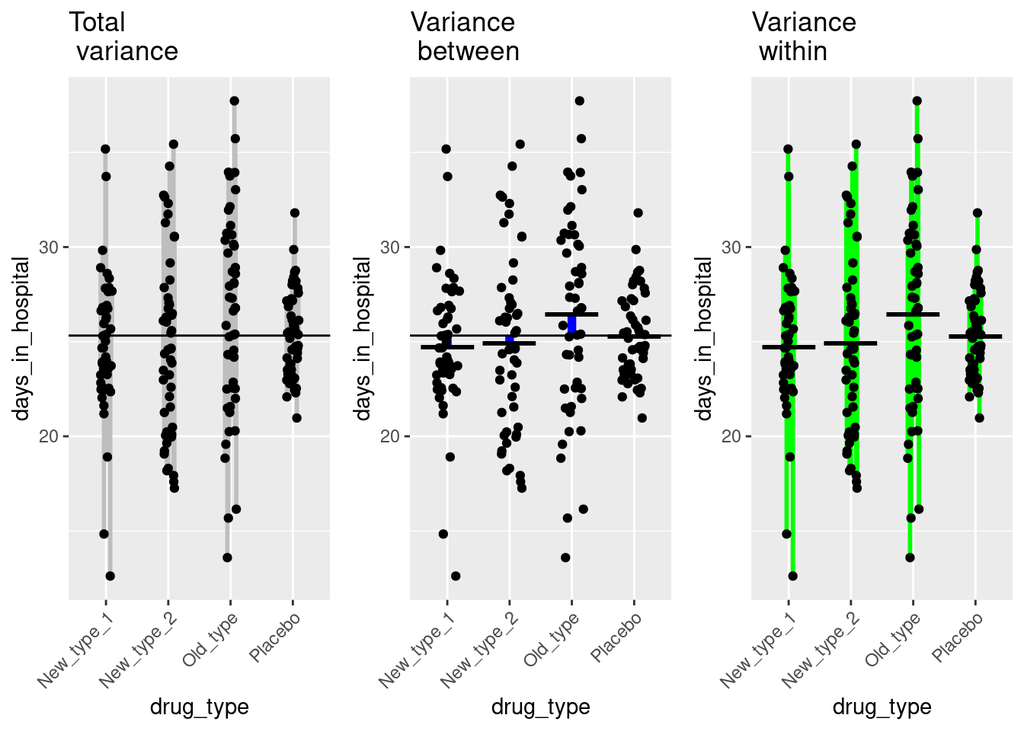

```r
df$drug_type <- factor(df$drug_type)
total <- ggplot(df, aes(x = drug_type, y = days_in_hospital))+
         geom_linerange(aes(x=drug_type, ymax=days_in_hospital, ymin = mean(df$days_in_hospital)), size = 1,color = "grey", position = position_jitter(width = 0.1, seed = 1L))+
  geom_hline(yintercept = mean(df$days_in_hospital))+
  geom_point(position = position_jitter(width = 0.1, seed = 1L)) +ggtitle("Total \n variance")+theme(axis.text.x = element_text(angle = 45, hjust = 1))

gr_mean<-df %>% group_by(drug_type) %>% summarise(mean = mean(days_in_hospital))

two_pic<-right_join(x = df, y = gr_mean)
hline <- data.frame(drug_type=levels(df$drug_type), v=gr_mean$mean)


resid<-ggplot(two_pic, aes(x = drug_type, y = days_in_hospital)) + geom_linerange(aes(x = drug_type, ymax = days_in_hospital, ymin = mean), size = 1,color = "green", position = position_jitter(width = 0.1, seed = 1L)) +geom_point(position = position_jitter(width = 0.1, seed = 1L)) +geom_point(data=hline, aes(drug_type, v), shape=95, size=15) +ggtitle("Variance \n within")+theme(axis.text.x = element_text(angle = 45, hjust = 1))

factor <- ggplot() +  geom_linerange(data = gr_mean, aes(x= drug_type, ymax = mean, ymin = mean(df$days_in_hospital)), color = "blue", size = 2)+geom_point(data = two_pic, aes(x = drug_type, y = days_in_hospital), position = position_jitter(width = 0.2, seed = 1L)) +geom_point(data=hline, aes(drug_type, v), shape=95, size=15) +geom_hline(yintercept = mean(df$days_in_hospital)) + ggtitle("Variance \n between")+theme(axis.text.x = element_text(angle = 45, hjust = 1))


grid.arrange(total, factor, resid, nrow = 1)
```

After visualizing the variances, we can use the F-test of ANOVA:

```r
res.aov <- aov(days_in_hospital ~ drug_type, data = df)
summary(res.aov)
```

```
##              Df Sum Sq Mean Sq F value Pr(>F)
## drug_type     3     89   29.66   1.701  0.168
## Residuals   196   3417   17.43
```

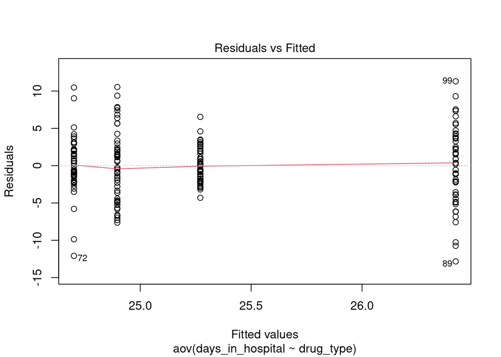

```r
plot(res.aov, 1)
```

Based on this there is no significant difference between the days spent in the hospital in groups taking different types of drugs.

ANOVA calculation by another function, take linear model:

```r
mod_df <- lm(days_in_hospital ~ drug_type, data = df)
summary(mod_df)
```

```
##
## Call:
## lm(formula = days_in_hospital ~ drug_type, data = df)
##
## Residuals:
##      Min       1Q   Median       3Q      Max
## -12.8321  -2.2052  -0.2613   2.2833  11.3025
##
## Coefficients:
##                     Estimate Std. Error t value Pr(>|t|)
## (Intercept)          24.7011     0.5905  41.834   <2e-16 ***
## drug_typeNew_type_2   0.1955     0.8350   0.234   0.8152
## drug_typeOld_type     1.7210     0.8350   2.061   0.0406 *
## drug_typePlacebo      0.5697     0.8350   0.682   0.4959
## ---
## Signif. codes:  0 '***' 0.001 '**' 0.01 '*' 0.05 '.' 0.1 ' ' 1
##
## Residual standard error: 4.175 on 196 degrees of freedom
## Multiple R-squared:  0.02538,    Adjusted R-squared:  0.01046
## F-statistic: 1.701 on 3 and 196 DF,  p-value: 0.1681
```

```r
df_anova <- Anova(mod_df)
df_anova
```

```
## Anova Table (Type II tests)
##
## Response: days_in_hospital
##           Sum Sq  Df F value Pr(>F)
## drug_type   89.0   3  1.7012 0.1681
## Residuals 3416.7 196
```

The days that one stays in the hospital is not affected by the drug type taken (F = 1.7011706, p_value = 0.1681007, df_1 = 3, df_2 = 196). The result might be skewed, as some of the conditions required in order to perform the ANOVA test were not fulfilled. The ANOVA test is robust and not be affected as much, however, further statistical analysis could be necessary.